# Part I - (Prosperloan Data Exploration)

## Introduction

> Introduce the dataset

> This data set contains 113,937 loans with 81 variables on each loan, including loan amount, borrower rate (or interest rate), current loan status, borrower income, and many others. See this data dictionary to understand the dataset's variables. Data dictionary to understand the variables more form this link: https://docs.google.com/spreadsheets/d/1gDyi_L4UvIrLTEC6Wri5nbaMmkGmLQBk-Yx3z0XDEtI/edit#gid=0

Questions to guide Analysis. 1)What factors affect a loan’s outcome status?

2)What factors affects the borrower’s APR or interest rate?

3)Are there differences between loans depending on how large the original loan amount was?

## Preliminary Wrangling

```python
# import all packages and set plots to be embedded inline
import numpy as np
import pandas as pd
import matplotlib.pyplot as plt
import seaborn as sb

%matplotlib inline
```

> Load in your dataset and describe its properties through the questions below. Try and motivate your exploration goals through this section.

```python
loans_data=pd.read_csv('prosperLoanData.csv')
```

```python
# high-level overview of data shape and composition
print(loans_data.shape)
print(loans_data.dtypes)
print(loans_data.head(5))
```

```
(113937, 81)
ListingKey                              object
ListingNumber                            int64
ListingCreationDate                     object
CreditGrade                             object
Term                                     int64
LoanStatus                              object
ClosedDate                              object
BorrowerAPR                            float64
BorrowerRate                           float64
LenderYield                            float64
EstimatedEffectiveYield                float64
EstimatedLoss                          float64
EstimatedReturn                        float64
ProsperRating (numeric)                float64
ProsperRating (Alpha)                   object
ProsperScore                           float64
ListingCategory (numeric)                int64
BorrowerState                           object
Occupation                              object
EmploymentStatus                        object
EmploymentStatusDuration               float64
IsBorrowerHomeowner                       bool
CurrentlyInGroup                          bool
GroupKey                                object
DateCreditPulled                        object
CreditScoreRangeLower                  float64
CreditScoreRangeUpper                  float64
FirstRecordedCreditLine                 object
CurrentCreditLines                     float64
OpenCreditLines                        float64
                                        ...
TotalProsperLoans                      float64
TotalProsperPaymentsBilled             float64
OnTimeProsperPayments                  float64
ProsperPaymentsLessThanOneMonthLate    float64
ProsperPaymentsOneMonthPlusLate        float64
ProsperPrincipalBorrowed               float64
ProsperPrincipalOutstanding            float64
ScorexChangeAtTimeOfListing            float64
```

[output cut: 51 more lines]

```
   PercentFunded  Recommendations InvestmentFromFriendsCount  \
0            1.0                0                          0
1            1.0                0                          0
2            1.0                0                          0
3            1.0                0                          0
4            1.0                0                          0

  InvestmentFromFriendsAmount Investors
0                         0.0       258
1                         0.0         1
2                         0.0        41
3                         0.0       158
4                         0.0        20

[5 rows x 81 columns]
```

```python
#Make copies of original pieces of data
df_loans_clean = loans_data.copy()
df_loans_clean.info()
```

```
<class 'pandas.core.frame.DataFrame'>
RangeIndex: 113937 entries, 0 to 113936
Data columns (total 81 columns):
ListingKey                             113937 non-null object
ListingNumber                          113937 non-null int64
ListingCreationDate                    113937 non-null object
CreditGrade                            28953 non-null object
Term                                   113937 non-null int64
LoanStatus                             113937 non-null object
ClosedDate                             55089 non-null object
BorrowerAPR                            113912 non-null float64
BorrowerRate                           113937 non-null float64
LenderYield                            113937 non-null float64
EstimatedEffectiveYield                84853 non-null float64
EstimatedLoss                          84853 non-null float64
EstimatedReturn                        84853 non-null float64
ProsperRating (numeric)                84853 non-null float64
ProsperRating (Alpha)                  84853 non-null object
ProsperScore                           84853 non-null float64
ListingCategory (numeric)              113937 non-null int64
BorrowerState                          108422 non-null object
Occupation                             110349 non-null object
EmploymentStatus                       111682 non-null object
EmploymentStatusDuration               106312 non-null float64
IsBorrowerHomeowner                    113937 non-null bool
CurrentlyInGroup                       113937 non-null bool
GroupKey                               13341 non-null object
DateCreditPulled                       113937 non-null object
CreditScoreRangeLower                  113346 non-null float64
CreditScoreRangeUpper                  113346 non-null float64
FirstRecordedCreditLine                113240 non-null object
CurrentCreditLines                     106333 non-null float64
OpenCreditLines                        106333 non-null float64
TotalCreditLinespast7years             113240 non-null float64
OpenRevolvingAccounts                  113937 non-null int64
OpenRevolvingMonthlyPayment            113937 non-null float64
InquiriesLast6Months                   113240 non-null float64
TotalInquiries                         112778 non-null float64
CurrentDelinquencies                   113240 non-null float64
AmountDelinquent                       106315 non-null float64
```

[output cut: 31 more lines]

```
LP_CustomerPayments                    113937 non-null float64
LP_CustomerPrincipalPayments           113937 non-null float64
LP_InterestandFees                     113937 non-null float64
LP_ServiceFees                         113937 non-null float64
LP_CollectionFees                      113937 non-null float64
LP_GrossPrincipalLoss                  113937 non-null float64
LP_NetPrincipalLoss                    113937 non-null float64
LP_NonPrincipalRecoverypayments        113937 non-null float64
PercentFunded                          113937 non-null float64
Recommendations                        113937 non-null int64
InvestmentFromFriendsCount             113937 non-null int64
InvestmentFromFriendsAmount            113937 non-null float64
Investors                              113937 non-null int64
dtypes: bool(3), float64(50), int64(11), object(17)
memory usage: 68.1+ MB
```

#### Change the columns name to lowercase for consistency

```python
df_loans_clean.columns
```

```
Index(['ListingKey', 'ListingNumber', 'ListingCreationDate', 'CreditGrade',
       'Term', 'LoanStatus', 'ClosedDate', 'BorrowerAPR', 'BorrowerRate',
       'LenderYield', 'EstimatedEffectiveYield', 'EstimatedLoss',
       'EstimatedReturn', 'ProsperRating (numeric)', 'ProsperRating (Alpha)',
       'ProsperScore', 'ListingCategory (numeric)', 'BorrowerState',
       'Occupation', 'EmploymentStatus', 'EmploymentStatusDuration',
       'IsBorrowerHomeowner', 'CurrentlyInGroup', 'GroupKey',
       'DateCreditPulled', 'CreditScoreRangeLower', 'CreditScoreRangeUpper',
       'FirstRecordedCreditLine', 'CurrentCreditLines', 'OpenCreditLines',
       'TotalCreditLinespast7years', 'OpenRevolvingAccounts',
       'OpenRevolvingMonthlyPayment', 'InquiriesLast6Months', 'TotalInquiries',
       'CurrentDelinquencies', 'AmountDelinquent', 'DelinquenciesLast7Years',
       'PublicRecordsLast10Years', 'PublicRecordsLast12Months',
       'RevolvingCreditBalance', 'BankcardUtilization',
       'AvailableBankcardCredit', 'TotalTrades',
       'TradesNeverDelinquent (percentage)', 'TradesOpenedLast6Months',
       'DebtToIncomeRatio', 'IncomeRange', 'IncomeVerifiable',
       'StatedMonthlyIncome', 'LoanKey', 'TotalProsperLoans',
       'TotalProsperPaymentsBilled', 'OnTimeProsperPayments',
       'ProsperPaymentsLessThanOneMonthLate',
       'ProsperPaymentsOneMonthPlusLate', 'ProsperPrincipalBorrowed',
       'ProsperPrincipalOutstanding', 'ScorexChangeAtTimeOfListing',
       'LoanCurrentDaysDelinquent', 'LoanFirstDefaultedCycleNumber',
       'LoanMonthsSinceOrigination', 'LoanNumber', 'LoanOriginalAmount',
       'LoanOriginationDate', 'LoanOriginationQuarter', 'MemberKey',
       'MonthlyLoanPayment', 'LP_CustomerPayments',
       'LP_CustomerPrincipalPayments', 'LP_InterestandFees', 'LP_ServiceFees',
       'LP_CollectionFees', 'LP_GrossPrincipalLoss', 'LP_NetPrincipalLoss',
       'LP_NonPrincipalRecoverypayments', 'PercentFunded', 'Recommendations',
       'InvestmentFromFriendsCount', 'InvestmentFromFriendsAmount',
       'Investors'],
      dtype='object')
```

```python
#Apply lower string to all columns and repalce space with underscores.
df_loans_clean.columns = map(str.lower, df_loans_clean.columns)
df_loans_clean.columns = df_loans_clean.columns.str.replace(' ', '_')
```

```python
df_loans_clean.columns
```

```
Index(['listingkey', 'listingnumber', 'listingcreationdate', 'creditgrade',
       'term', 'loanstatus', 'closeddate', 'borrowerapr', 'borrowerrate',
       'lenderyield', 'estimatedeffectiveyield', 'estimatedloss',
       'estimatedreturn', 'prosperrating_(numeric)', 'prosperrating_(alpha)',
       'prosperscore', 'listingcategory_(numeric)', 'borrowerstate',
       'occupation', 'employmentstatus', 'employmentstatusduration',
       'isborrowerhomeowner', 'currentlyingroup', 'groupkey',
       'datecreditpulled', 'creditscorerangelower', 'creditscorerangeupper',
       'firstrecordedcreditline', 'currentcreditlines', 'opencreditlines',
       'totalcreditlinespast7years', 'openrevolvingaccounts',
       'openrevolvingmonthlypayment', 'inquirieslast6months', 'totalinquiries',
       'currentdelinquencies', 'amountdelinquent', 'delinquencieslast7years',
       'publicrecordslast10years', 'publicrecordslast12months',
       'revolvingcreditbalance', 'bankcardutilization',
       'availablebankcardcredit', 'totaltrades',
       'tradesneverdelinquent_(percentage)', 'tradesopenedlast6months',
       'debttoincomeratio', 'incomerange', 'incomeverifiable',
       'statedmonthlyincome', 'loankey', 'totalprosperloans',
       'totalprosperpaymentsbilled', 'ontimeprosperpayments',
       'prosperpaymentslessthanonemonthlate',
       'prosperpaymentsonemonthpluslate', 'prosperprincipalborrowed',
       'prosperprincipaloutstanding', 'scorexchangeattimeoflisting',
       'loancurrentdaysdelinquent', 'loanfirstdefaultedcyclenumber',
       'loanmonthssinceorigination', 'loannumber', 'loanoriginalamount',
       'loanoriginationdate', 'loanoriginationquarter', 'memberkey',
       'monthlyloanpayment', 'lp_customerpayments',
       'lp_customerprincipalpayments', 'lp_interestandfees', 'lp_servicefees',
       'lp_collectionfees', 'lp_grossprincipalloss', 'lp_netprincipalloss',
       'lp_nonprincipalrecoverypayments', 'percentfunded', 'recommendations',
       'investmentfromfriendscount', 'investmentfromfriendsamount',
       'investors'],
      dtype='object')
```

Select columns thats is relevant to analysis

```python
df_loans = df_loans_clean.loc[:, ['listingcreationdate', 'term', 'loanstatus', 'closeddate', 'borrowerapr',
                         'borrowerrate', 'lenderyield', 'prosperrating_(alpha)', 'prosperscore', 'listingcategory_(numeric)',
                         'borrowerstate', 'occupation', 'employmentstatus', 'amountdelinquent',
                         'incomerange', 'statedmonthlyincome',
                         'loancurrentdaysdelinquent',
                         'loanoriginalamount', 'loanoriginationdate',
                         'monthlyloanpayment', 'lp_servicefees', 'investors','debttoincomeratio']]
df_loans.columns
```

```
Index(['listingcreationdate', 'term', 'loanstatus', 'closeddate',
       'borrowerapr', 'borrowerrate', 'lenderyield', 'prosperrating_(alpha)',
       'prosperscore', 'listingcategory_(numeric)', 'borrowerstate',
       'occupation', 'employmentstatus', 'amountdelinquent', 'incomerange',
       'statedmonthlyincome', 'loancurrentdaysdelinquent',
       'loanoriginalamount', 'loanoriginationdate', 'monthlyloanpayment',
       'lp_servicefees', 'investors', 'debttoincomeratio'],
      dtype='object')
```

```python
df_loans.info()
```

```
<class 'pandas.core.frame.DataFrame'>
RangeIndex: 113937 entries, 0 to 113936
Data columns (total 23 columns):
listingcreationdate          113937 non-null object
term                         113937 non-null int64
loanstatus                   113937 non-null object
closeddate                   55089 non-null object
borrowerapr                  113912 non-null float64
borrowerrate                 113937 non-null float64
lenderyield                  113937 non-null float64
prosperrating_(alpha)        84853 non-null object
prosperscore                 84853 non-null float64
listingcategory_(numeric)    113937 non-null int64
borrowerstate                108422 non-null object
occupation                   110349 non-null object
employmentstatus             111682 non-null object
amountdelinquent             106315 non-null float64
incomerange                  113937 non-null object
statedmonthlyincome          113937 non-null float64
loancurrentdaysdelinquent    113937 non-null int64
loanoriginalamount           113937 non-null int64
loanoriginationdate          113937 non-null object
monthlyloanpayment           113937 non-null float64
lp_servicefees               113937 non-null float64
investors                    113937 non-null int64
debttoincomeratio            105383 non-null float64
dtypes: float64(9), int64(5), object(9)
memory usage: 20.0+ MB
```

```python
df_loans.isnull().sum()
```

```
listingcreationdate              0
term                             0
loanstatus                       0
closeddate                   58848
borrowerapr                     25
borrowerrate                     0
lenderyield                      0
prosperrating_(alpha)        29084
prosperscore                 29084
listingcategory_(numeric)        0
borrowerstate                 5515
occupation                    3588
employmentstatus              2255
amountdelinquent              7622
incomerange                      0
statedmonthlyincome              0
loancurrentdaysdelinquent        0
loanoriginalamount               0
loanoriginationdate              0
monthlyloanpayment               0
lp_servicefees                   0
investors                        0
debttoincomeratio             8554
dtype: int64
```

```python
#Drop null values
df_loans.dropna(subset =['closeddate', 'borrowerapr','borrowerstate', \
                            'occupation', 'employmentstatus','debttoincomeratio'], inplace = True)
```

```python
df_loans.info()
```

```
<class 'pandas.core.frame.DataFrame'>
Int64Index: 44548 entries, 0 to 113935
Data columns (total 23 columns):
listingcreationdate          44548 non-null object
term                         44548 non-null int64
loanstatus                   44548 non-null object
closeddate                   44548 non-null object
borrowerapr                  44548 non-null float64
borrowerrate                 44548 non-null float64
lenderyield                  44548 non-null float64
prosperrating_(alpha)        23020 non-null object
prosperscore                 23020 non-null float64
listingcategory_(numeric)    44548 non-null int64
borrowerstate                44548 non-null object
occupation                   44548 non-null object
employmentstatus             44548 non-null object
amountdelinquent             41651 non-null float64
incomerange                  44548 non-null object
statedmonthlyincome          44548 non-null float64
loancurrentdaysdelinquent    44548 non-null int64
loanoriginalamount           44548 non-null int64
loanoriginationdate          44548 non-null object
monthlyloanpayment           44548 non-null float64
lp_servicefees               44548 non-null float64
investors                    44548 non-null int64
debttoincomeratio            44548 non-null float64
dtypes: float64(9), int64(5), object(9)
memory usage: 8.2+ MB
```

### What is the structure of your dataset?

> There are 113,937 listings in the dataset with 81 features. Most variables are numeric, some are categorical, boolean and date. Variables like ProsperRating (Alpha) and IncomeRange can be ordered factor variables with the following levels.

ProsperRating (Alpha): HR, E, D, C, B, A, AA (worst to best)

Some of the variables have a lot of null values, such as variables prosperrating and prosperscore, which I'll need to deal with later.

Some variables are not of much use, such as listingkey, listingnumber, of other identifiers. These columns I will remove later.

### What is/are the main feature(s) of interest in your dataset?

> I am most interested in the loanstatus variable to enable me see factors that afftect loan repayment. BorrowerAPR: The Borrower's Annual Percentage Rate (APR) for the loan. ProsperScore: A custom risk score built using historical Prosper data. The score ranges from 1-10, with 10 being the best, or * lowest risk score. Applicable for loans originated after July 2009. LoanOriginationDate: The date the loan was originated. LenderYield: The Lender yield on the loan. Lender yield is equal to the interest rate on the loan less the servicing fee. listingcategory_(numeric):The category of the listing that the borrower selected when posting their listing: 0 - Not Available, 1 - Debt Consolidation, 2 - Home Improvement, 3 - Business, 4 - Personal Loan, 5 - Student Use, 6 - Auto, 7- Other, 8 - Baby&Adoption, 9 - Boat, 10 - Cosmetic Procedure, 11 - Engagement Ring, 12 - Green Loans, 13 - Household Expenses, 14 - Large Purchases, 15 - Medical/Dental, 16 - Motorcycle, 17 - RV, 18 - Taxes, 19 - Vacation, 20 - Wedding Loans

### What features in the dataset do you think will help support your investigation into your feature(s) of interest?

> I expect that variables that influence borrowers' personal circumstances would have an effect on their ability to repay loans or default, factors such as EmploymentStatus, borrowerapr, loanstatus, IncomeRange, etc.

```python
#Adjust columns to datetime datatypes
df_loans['listingcreationdate'] = pd.to_datetime(df_loans['listingcreationdate'])
df_loans['closeddate'] = pd.to_datetime(df_loans['closeddate'])
df_loans['loanoriginationdate'] = pd.to_datetime(df_loans['loanoriginationdate'])
```

```python
df_loans_clean.duplicated().sum()
```

```
0
```

```python
df_loans_clean['incomerange'].value_counts()
```

```
$25,000-49,999    32192
$50,000-74,999    31050
$100,000+         17337
$75,000-99,999    16916
Not displayed      7741
$1-24,999          7274
Not employed        806
$0                  621
Name: incomerange, dtype: int64
```

```python
df_loans_clean['employmentstatus'].value_counts()
```

```
Employed         67322
Full-time        26355
Self-employed     6134
Not available     5347
Other             3806
Part-time         1088
Not employed       835
Retired            795
Name: employmentstatus, dtype: int64
```

```python
df_loans.describe()
```

|  | term | borrowerapr | borrowerrate | lenderyield | prosperscore | listingcategory_(numeric) | amountdelinquent | statedmonthlyincome | loancurrentdaysdelinquent | loanoriginalamount | monthlyloanpayment | lp_servicefees | investors | debttoincomeratio |
| --- | --- | --- | --- | --- | --- | --- | --- | --- | --- | --- | --- | --- | --- | --- |
| count | 44548.000000 | 44548.000000 | 44548.000000 | 44548.000000 | 23020.000000 | 44548.000000 | 41651.000000 | 44548.000000 | 44548.000000 | 44548.000000 | 44548.000000 | 44548.000000 | 44548.000000 | 44548.000000 |
| mean | 37.074796 | 0.222193 | 0.199492 | 0.189363 | 6.422328 | 2.625325 | 1060.667259 | 5206.215012 | 302.229079 | 6456.779900 | 229.704857 | -56.703402 | 111.060878 | 0.287027 |
| std | 7.715312 | 0.089075 | 0.082218 | 0.081715 | 2.280249 | 3.466406 | 6816.157110 | 5123.764742 | 615.279873 | 5293.809696 | 187.178607 | 60.192179 | 113.308572 | 0.686261 |
| min | 12.000000 | 0.006530 | 0.000000 | -0.010000 | 1.000000 | 0.000000 | 0.000000 | 0.000000 | 0.000000 | 1000.000000 | 0.000000 | -664.870000 | 1.000000 | 0.000000 |
| 25% | 36.000000 | 0.147845 | 0.131200 | 0.122000 | 5.000000 | 1.000000 | 0.000000 | 2916.666667 | 0.000000 | 3000.000000 | 102.740000 | -78.510000 | 34.000000 | 0.130000 |
| 50% | 36.000000 | 0.213720 | 0.190200 | 0.180000 | 7.000000 | 1.000000 | 0.000000 | 4333.333333 | 0.000000 | 5000.000000 | 173.710000 | -37.400000 | 74.000000 | 0.200000 |
| 75% | 36.000000 | 0.295453 | 0.269900 | 0.258400 | 8.000000 | 4.000000 | 0.000000 | 6333.333333 | 217.000000 | 8500.000000 | 307.570000 | -15.980000 | 151.000000 | 0.310000 |
| max | 60.000000 | 0.423950 | 0.360000 | 0.340000 | 11.000000 | 20.000000 | 444745.000000 | 483333.333333 | 2599.000000 | 35000.000000 | 2251.510000 | 32.060000 | 1189.000000 | 10.010000 |

```python
# Convert ProsperRating & IncomeRange into ordered categorical types
ordinal_var_dict = {'prosperrating_(alpha)': ['N/A','HR','E','D','C', 'B', 'A', 'AA'],
                    'incomerange':['$0','$1-24,999','$25,000-49,999','$50,000-74,999','$75,000-99,999','$100,000+']

                  }
for var in ordinal_var_dict:
    ordered_var = pd.api.types.CategoricalDtype(ordered = True, categories = ordinal_var_dict[var])
    df_loans[var] = df_loans[var].astype(ordered_var)
```

```python
df_loans['prosperrating_(alpha)'].value_counts()
```

```
D      5096
C      3442
A      3392
E      3207
B      3168
HR     3003
AA     1712
N/A       0
Name: prosperrating_(alpha), dtype: int64
```

```python
df_loans['incomerange'].value_counts()
```

```
$25,000-49,999    14568
$50,000-74,999    11712
$75,000-99,999     5955
$100,000+          5476
$1-24,999          3783
$0                    0
Name: incomerange, dtype: int64
```

```python
df_loans['loanstatus'].value_counts()
```

```
Completed     31086
Chargedoff     9613
Defaulted      3848
Cancelled         1
Name: loanstatus, dtype: int64
```

```python
#Change datatype for all other categorical columns
df_loans['employmentstatus'] = df_loans['employmentstatus'].astype('category')
df_loans['occupation'] = df_loans['occupation'].astype('category')
df_loans['loanstatus']= df_loans['loanstatus'].astype('category')
df_loans['borrowerstate)'] = df_loans['borrowerstate'].astype('category')
```

```python
print(df_loans.dtypes)
```

```
listingcreationdate          datetime64[ns]
term                                  int64
loanstatus                         category
closeddate                   datetime64[ns]
borrowerapr                         float64
borrowerrate                        float64
lenderyield                         float64
prosperrating_(alpha)              category
prosperscore                        float64
listingcategory_(numeric)             int64
borrowerstate                        object
occupation                         category
employmentstatus                   category
amountdelinquent                    float64
incomerange                        category
statedmonthlyincome                 float64
loancurrentdaysdelinquent             int64
loanoriginalamount                    int64
loanoriginationdate          datetime64[ns]
monthlyloanpayment                  float64
lp_servicefees                      float64
investors                             int64
debttoincomeratio                   float64
borrowerstate)                     category
dtype: object
```

```python
numeric_vars = ['term', 'borrowerapr', 'lenderyield', 'prosperrating_(alpha)', 'prosperscore', 'listingcategory_(numeric)', 'amountdelinquent','incomerange','statedmonthlyincome','loancurrentdaysdelinquent','loanoriginalamount','monthlyloanpayment','monthlyloanpayment','lp_servicefees','investors']
categoric_vars = ['listingcreationdate', 'closeddate', 'loanstatus','closeddate','borrowerstate','occupation','employmentstatus','loanoriginationdate','investors']
```

I removed the current loan status to allow me classify loanstatus as default or no default.

```python
loan_analysis = df_loans[df_loans['loanstatus'].isin(['Completed', 'Chargedoff', 'Defaulted', 'Past Due (1-15 days)',
                                                          'Past Due (31-60 days)', 'Past Due (61-90 days)', 'Past Due (91-120 days)'\
                                                         'Past Due (16-30 days)', 'Past Due (>120 days)'])]
```

df_loans[df_loans['loanstatus'] == 'Completed']['loan_paid'] = '1'

# No default loan is 0 while defualt loanstatus is 1.

```python
loan_analysis['default'] = np.where(loan_analysis['loanstatus'] == 'Completed', 0, 1)
```

```python
loan_analysis['default'].value_counts()
```

```
0    31086
1    13461
Name: default, dtype: int64
```

## What is the distribution shape of Borrowerapr variable?

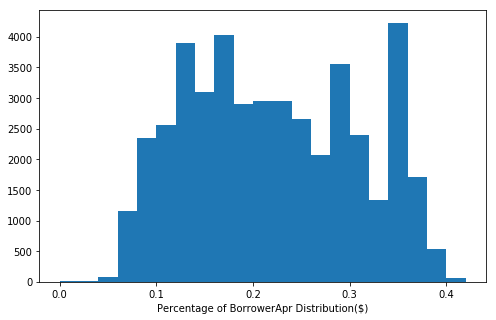

```python
# univariate plots of borrowerapr
bins = np.arange(0, df_loans['borrowerapr'].max() + 0.01, 0.02);
plt.figure(figsize=[8, 5])
plt.hist(data = df_loans, x = 'borrowerapr', bins = bins)
plt.xlabel('Percentage of BorrowerApr Distribution($)')
plt.show()
```

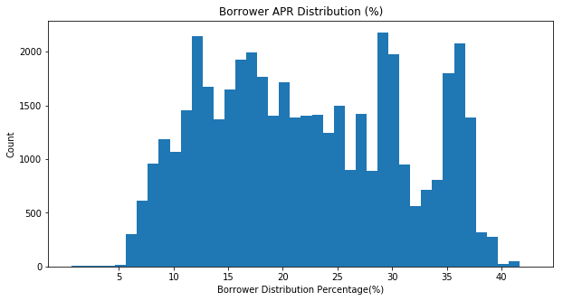

```python
# univariate plots of borrowerapr using different binsize and %.
binsize = 1
borrowed_APR_percentage = df_loans['borrowerapr']*100
bins = np.arange(df_loans['borrowerapr'].min()*100, df_loans['borrowerapr'].max()*100+binsize, binsize)

plt.figure(figsize=[10, 5])
plt.hist(x = borrowed_APR_percentage, bins = bins)
plt.title('Borrower APR Distribution (%)')
plt.xlabel('Borrower Distribution Percentage(%)')
plt.ylabel('Count')
plt.xticks([5, 10, 15, 20, 25, 30, 35, 40], ['5','10', '15', '20', '25', '30', '35', '40'])
plt.show()
```

The prosperloan borrowerapr shows that it bimodial skewed disribution,highest peak at 30% and above 35%.

## What is the distribution of prsoperrating ?

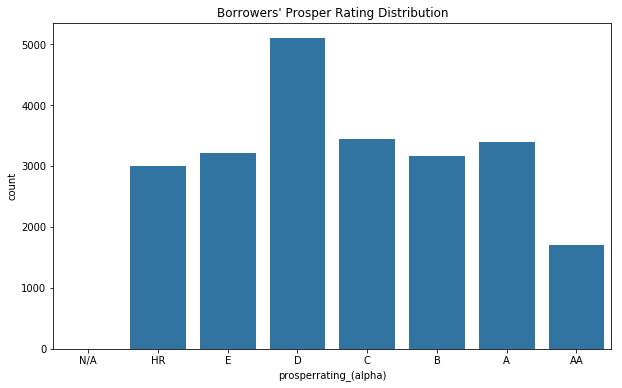

```python
# univariate plots of prosperrating_(alpha)
base_color = sb.color_palette()[0]
plt.subplots(figsize = (10, 6))
sb.countplot(data = df_loans, x = 'prosperrating_(alpha)', color = base_color);
plt.title("Borrowers' Prosper Rating Distribution");
```

The prosperloan prosperrating_(alpha) show that most borrower rating is D.

## What is the Frequency of prosperscore variable?

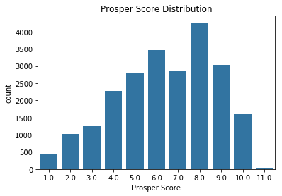

```python
#Prosper Score Distribution.
base_color = sb.color_palette()[0]
sb.countplot(data=df_loans, x= 'prosperscore', color=base_color)
plt.title('Prosper Score Distribution')
plt.xlabel('Prosper Score');
```

## Is the Borrowerrate Distribution normal?

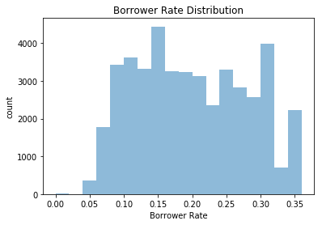

```python
# univariate plots of borrowerrate on loan_analysis
base_color = sb.color_palette()[0]
bins = np.arange(0, loan_analysis['borrowerrate'].max() + 0.01, 0.02);
plt.hist(data = loan_analysis, x = 'borrowerrate', bins = bins, alpha = 0.5, color = base_color);
plt.title('Borrower Rate Distribution');
plt.xlabel('Borrower Rate');
plt.ylabel('count');
```

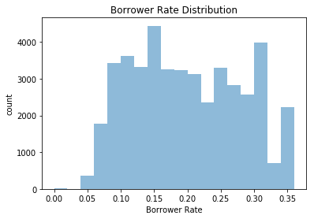

```python
# univariate plots of borrowerrate
base_color = sb.color_palette()[0]
bins = np.arange(0, df_loans['borrowerrate'].max() + 0.01, 0.02);
plt.hist(data = df_loans, x = 'borrowerrate', bins = bins, alpha = 0.5, color = base_color);
plt.title('Borrower Rate Distribution');
plt.xlabel('Borrower Rate');
plt.ylabel('count');
```

The borrower rate has 2 peaks at 0.15 and 0.31.

## What is the spread of LoanOriginalAmount variable?

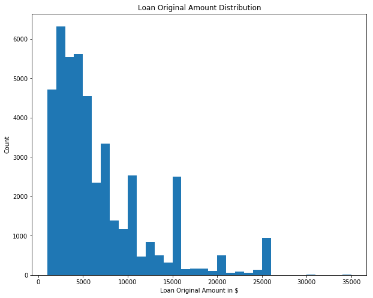

```python
# Loan Original Amount Distribution
binsize = 1000
bins = np.arange(df_loans['loanoriginalamount'].min(), df_loans['loanoriginalamount'].max()+binsize, binsize)
plt.figure(figsize=[10, 8])
plt.hist(data = df_loans, x = 'loanoriginalamount', bins = bins)
plt.title('Loan Original Amount Distribution')
plt.xlabel('Loan Original Amount in $')
plt.ylabel('Count')
plt.show()
```

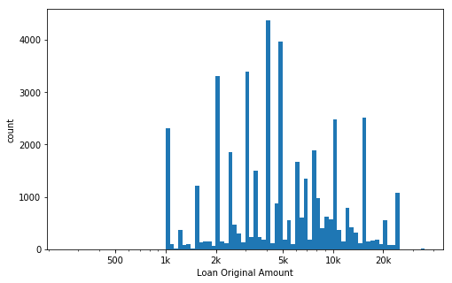

```python
# there's a long tail in the distribution, so let's put it on a log scale instead
log_binsize = 0.025
bins = 10 ** np.arange(2.4, np.log10(df_loans['loanoriginalamount'].max())+log_binsize, log_binsize)

plt.figure(figsize=[8, 5])
plt.hist(data = df_loans, x = 'loanoriginalamount', bins = bins)
plt.xscale('log')
plt.xticks([500, 1e3, 2e3, 5e3, 1e4, 2e4], [500, '1k', '2k', '5k', '10k', '20k'])
plt.xlabel('Loan Original Amount')
plt.ylabel('count')
plt.show()
```

Loanoriginalamount has a long-tailed distribution,so i plotted on a log-scale, the loan original amount distribution looks normally distributed, with peak between at 4k, and a second peak a little below 5k.

## What is the Frequency Listing Catergory ?

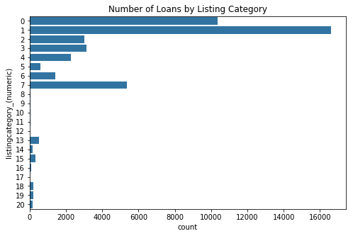

```python
# univariate plots of listingcategory_(numeric)
plt.figure(figsize=[8, 5])
list_category = df_loans['listingcategory_(numeric)'].unique()
list_category.sort()
plt.xlabel('Loan Original Amount')
base_color = sb.color_palette()[0]
sb.countplot(data = df_loans, y = 'listingcategory_(numeric)', color = base_color,order=list_category);
plt.title('Number of Loans by Listing Category');
```

The category of the listing that the borrower selected when posting their listing: shows that 1 - Debt Consolidation is the most reason borrower obtain loans.

The Distribution of Borrowerstate?

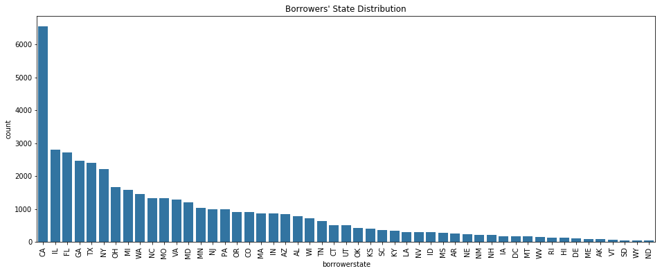

```python
# univariate plots of borrowerstate
borrower_state = df_loans['borrowerstate'].value_counts().index
plt.subplots(figsize = (16, 6));
sb.countplot(data = df_loans, x = 'borrowerstate', color = base_color, order = borrower_state);
plt.xticks(rotation = 90);
plt.title("Borrowers' State Distribution");
```

The state with most borrower is CA(California),Ilinoss and Florida.

## What is the distribution of occupation ?

```python
#To remove the others and professinal from the occupation column.
occupation = df_loans[(df_loans['occupation']!='Other')&(df_loans['occupation']!='Professional')]
occupation['occupation'].value_counts()
```

```
Computer Programmer                   2142
Administrative Assistant              1713
Analyst                               1630
Executive                             1545
Clerical                              1476
Teacher                               1462
Sales - Commission                    1415
Accountant/CPA                        1328
Sales - Retail                        1123
Skilled Labor                         1035
Retail Management                     1016
Nurse (RN)                             753
Military Enlisted                      715
Laborer                                636
Police Officer/Correction Officer      623
Construction                           616
Civil Service                          607
Engineer - Mechanical                  565
Truck Driver                           552
Engineer - Electrical                  502
Food Service                           451
Medical Technician                     439
Food Service Management                436
Attorney                               342
Social Worker                          292
Tradesman - Mechanic                   291
Postal Service                         256
Realtor                                242
Professor                              214
Fireman                                214
                                      ...
Student - College Graduate Student     138
Teacher's Aide                         123
Bus Driver                             115
Student - College Senior               105
Engineer - Chemical                    102
Architect                              101
Principal                               99
Pilot - Private/Commercial              89
Pharmacist                              88
Clergy                                  75
Student - College Junior                66
Chemist                                 65
Landscaping                             64
Biologist                               60
Car Dealer                              59
Flight Attendant                        58
Religious                               58
Student - College Sophomore             43
Tradesman - Plumber                     43
Homemaker                               37
Tradesman - Carpenter                   37
Psychologist                            36
Investor                                26
Student - College Freshman              24
Student - Community College             18
Dentist                                 17
Student - Technical School               9
Judge                                    2
Professional                             0
Other                                    0
Name: occupation, Length: 67, dtype: int64
```

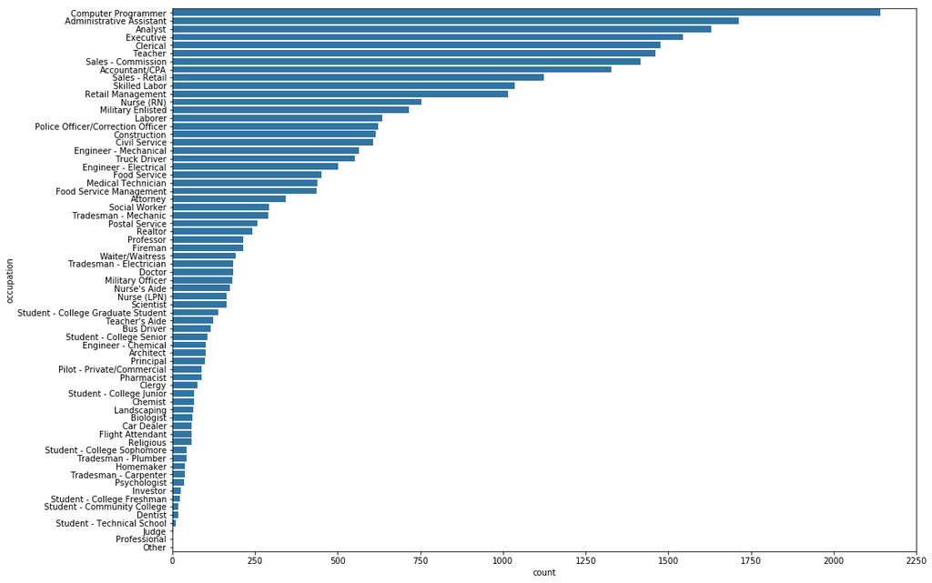

```python
#Plot the occupation type on a Horizontal bar chart
plt.subplots(figsize = (16, 12))
base_color = sb.color_palette()[0]
type_order = occupation['occupation'].value_counts().index
sb.countplot(data=occupation, y='occupation', color=base_color, order=type_order);
```

The Occupation selected by the Borrower at the time they created the listing shows that computer programmer is the highest in identified occupation.

## What's is the Distribution of Employmentstatus?

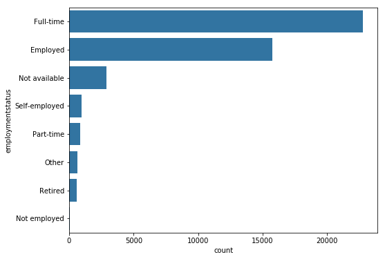

```python
# Plot the Prosper_loan type on a horizontal bar chart
plt.subplots(figsize = (8, 6))
base_color = sb.color_palette()[0]
type_order = df_loans['employmentstatus'].value_counts().index
sb.countplot(data=df_loans, y='employmentstatus', color=base_color, order=type_order);
```

The employment status of the borrower at the time they posted the listing shows that most borrower is employed.

## What's is the Distribution of incomerange?

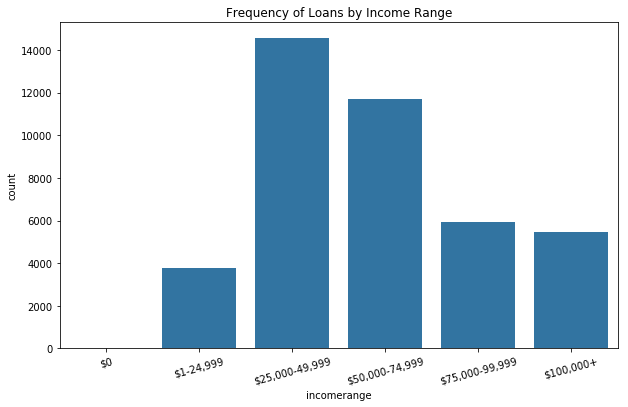

```python
# plotting incomerange on a standard scale
plt.subplots(figsize = (10, 6))
base_color = sb.color_palette()[0]
sb.countplot(data = df_loans, x = 'incomerange', color = base_color);
plt.xticks(rotation = 15);
plt.title('Frequency of Loans by Income Range');
```

The income range of the borrower at the time the listing was created shows that peak ranges from $25,000-$49,99.

## What's is the Distribution of Term?

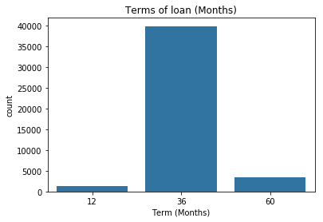

```python
#Plot the term type on a bar chart
base_color = sb.color_palette()[0]
sb.countplot(data=df_loans,x= 'term',color=base_color);
plt.title('Terms of loan (Months)')
plt.xlabel('Term (Months)');
```

The length of the loan expressed in months with 36 months the most common period duration.

## ## What's is the Distribution of LenderYield?

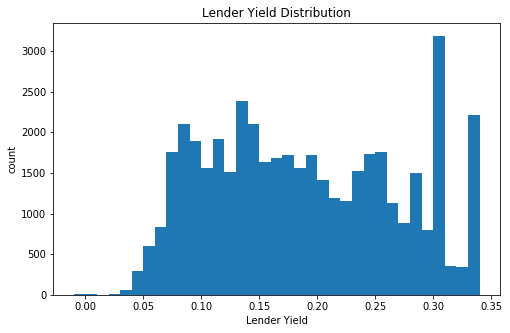

```python
#Lender Yield Distribution
binsize = 0.01
bins = np.arange(df_loans['lenderyield'].min(), df_loans['lenderyield'].max()+binsize, binsize)

plt.figure(figsize=[8, 5])
plt.hist(data = df_loans, x = 'lenderyield', bins = bins)
plt.xlabel('Lender Yield')
plt.title('Lender Yield Distribution')
plt.ylabel('count')
plt.show()
```

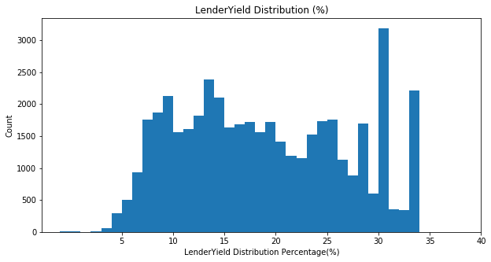

```python
#Distribution of lenderyield percentage.
binsize = 1
lenderyield_percentage = df_loans['lenderyield']*100
bins = np.arange(df_loans['lenderyield'].min()*100, df_loans['lenderyield'].max()*100+binsize, binsize)

plt.figure(figsize=[10, 5])
plt.hist(x = lenderyield_percentage, bins = bins)
plt.title('LenderYield Distribution (%)')
plt.xlabel('LenderYield Distribution Percentage(%)')
plt.ylabel('Count')
plt.xticks([5, 10, 15, 20, 25, 30, 35, 40], ['5','10', '15', '20', '25', '30', '35', '40'])
plt.show()
```

## What's is the Distribution of Monthlyloanpayment?

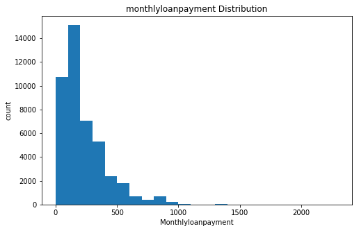

```python
#monthlyloanpayment Distribution
binsize = 100
bins = np.arange(df_loans['monthlyloanpayment'].min(), df_loans['monthlyloanpayment'].max()+binsize, binsize)

plt.figure(figsize=[8, 5])
plt.hist(data = df_loans, x = 'monthlyloanpayment', bins = bins)
plt.xlabel('Monthlyloanpayment')
plt.title('monthlyloanpayment Distribution')
plt.ylabel('count')
plt.show()
```

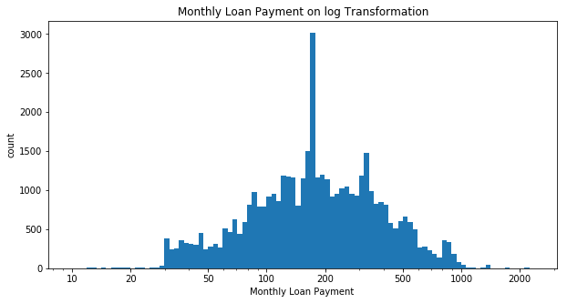

```python
#Monthlyloanpayment Distribution Using log-scale
log_binsize = 0.025
bins = 10 ** np.arange(1, np.log10(df_loans['monthlyloanpayment'].max())+log_binsize, log_binsize)

plt.figure(figsize=[10, 5])
plt.hist(data = df_loans, x = 'monthlyloanpayment', bins = bins)
plt.xscale('log')
plt.xticks([10, 20, 50, 100, 200, 500, 1e3, 2e3], ['10', '20','50', '100', '200', '500', '1000', '2000'])
plt.xlabel('Monthly Loan Payment ')
plt.ylabel('count')
plt.title('Monthly Loan Payment on log Transformation')
plt.show()
```

## What's is the Distribution of Debttoincomeratio?

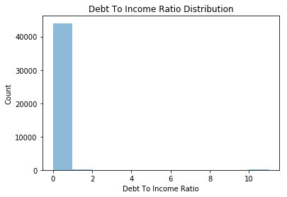

```python
# univariate plots of debttoincomeratio
bins = np.arange(0, df_loans['debttoincomeratio'].max() + 1, 1);
plt.hist(data = df_loans, x = 'debttoincomeratio', bins = bins, alpha = 0.5);
plt.title('Debt To Income Ratio Distribution');
plt.xlabel('Debt To Income Ratio');
plt.ylabel('Count');
```

Most of the borrowers have debt to income ratio between (0, 1).

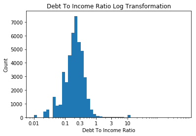

```python
#Debt to Incomre ratio on log transformation scale
bins = 10 ** np.arange(-2, 2.8 + 0.1, 0.1)
ticks = [0.01, 0.1, 0.3, 1, 3, 10]
labels = ['{}'.format(v) for v in ticks]
plt.hist(data = df_loans, x = 'debttoincomeratio', bins = bins);
plt.xscale('log');
plt.xticks(ticks, labels);
plt.title('Debt To Income Ratio Log Transformation');
plt.xlabel('Debt To Income Ratio');
plt.ylabel('Count');
```

Debt to income ratio has a long-tailed distribution. When plotted on a log-scale, the debttoincomeratio distribution looks roughly normally distributed, with peak before 0.3.

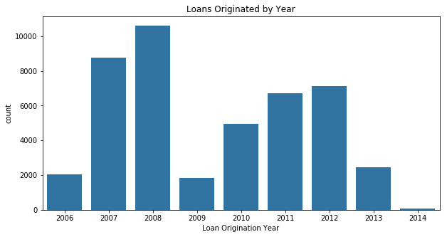

```python
# Loan Origination by Year Distribution
plt.figure(figsize=[10, 5])
sb.countplot(data=df_loans,x=df_loans['loanoriginationdate'].dt.year,color=base_color)
plt.title('Loans Originated by Year')
plt.xlabel('Loan Origination Year');
```

The Loan Origination Year showed a significant increase in 2008 compared to other years.

## Bivariate Exploration

> In this section, i investigated relationships between pairs of variables in the data. To make sure the variables that have been introduced in some previous section (univariate exploration).

```python
print(df_loans.dtypes)
```

```
listingcreationdate          datetime64[ns]
term                                  int64
loanstatus                         category
closeddate                   datetime64[ns]
borrowerapr                         float64
borrowerrate                        float64
lenderyield                         float64
prosperrating_(alpha)              category
prosperscore                        float64
listingcategory_(numeric)             int64
borrowerstate                        object
occupation                         category
employmentstatus                   category
amountdelinquent                    float64
incomerange                        category
statedmonthlyincome                 float64
loancurrentdaysdelinquent             int64
loanoriginalamount                    int64
loanoriginationdate          datetime64[ns]
monthlyloanpayment                  float64
lp_servicefees                      float64
investors                             int64
debttoincomeratio                   float64
borrowerstate)                     category
dtype: object
```

```python
numeric_vars = ['term', 'borrowerapr', 'lenderyield', 'prosperscore', 'amountdelinquent','statedmonthlyincome','loancurrentdaysdelinquent','loanoriginalamount','monthlyloanpayment','lp_servicefees','investors']
categoric_vars = ['listingcreationdate', 'closeddate', 'loanstatus','closeddate','borrowerstate','occupation','employmentstatus','loanoriginationdate']
```

## Is there correlation between Numeric Variable?

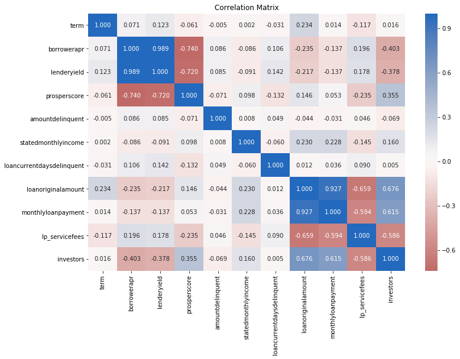

```python
plt.figure(figsize = [12, 8])
sb.heatmap(df_loans[numeric_vars].corr(), annot = True, fmt = '.3f',
           cmap = 'vlag_r', center = 0)
plt.title('Correlation Matrix')
plt.show()
```

Strong positive correlations between Lender yield and Borrower APR. Loanoriginalamount and Monthlyloanpayment is also positive correlation.

# Which incomerange is has most default?

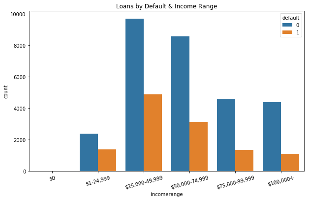

```python
# Let's look at rate of default across incomerange.
plt.subplots(figsize = (10, 6))
sb.countplot(data = loan_analysis, x = 'incomerange', hue = 'default');
plt.xticks(rotation = 15);
plt.title('Loans by Default & Income Range');
```

Loan default is peaks in the incomerange $25,000-$49,000.

## Which listingcategory_(numeric) is has most default?

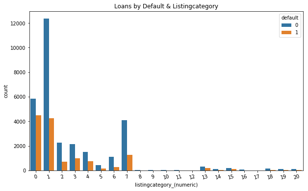

```python
# Let's look at rate of default across incomerange.
plt.subplots(figsize = (10, 6))
sb.countplot(data = loan_analysis, x = 'listingcategory_(numeric)', hue = 'default');
plt.xticks(rotation = 15);
plt.title('Loans by Default & Listingcategory');
```

## which employmentstatus has most borrowerapr?

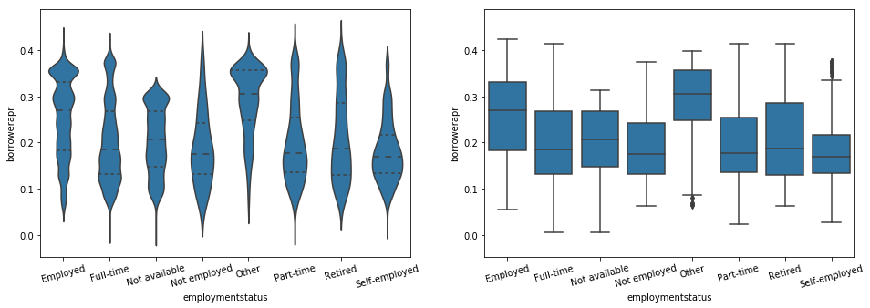

```python
# Step 4.  TWO PLOTS IN ONE FIGURE(voilinplot and boxplot)
plt.figure(figsize = [16, 5])
base_color = sb.color_palette()[0]

# LEFT plot: violin plot
plt.subplot(1, 2, 1)
#Let's return the axes object
ax1 = sb.violinplot(data=df_loans, x='employmentstatus', y='borrowerapr', color=base_color,inner='quartile')
plt.xticks(rotation=15);

# RIGHT plot: box plot
plt.subplot(1, 2, 2)
sb.boxplot(data=df_loans, x='employmentstatus', y='borrowerapr', color=base_color)
plt.xticks(rotation=15);
plt.ylim(ax1.get_ylim()); # set y-axis limits to be same as left plot
```

## which listingcategory has the most borrowerapr ?

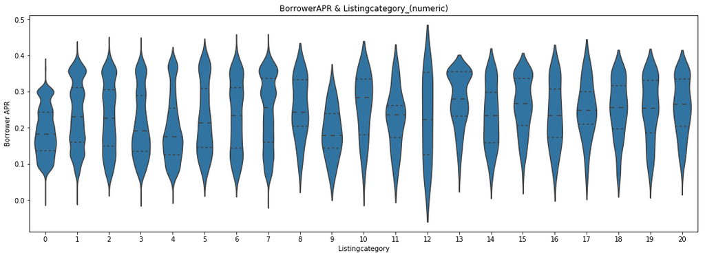

```python
#Plot the Borrowerapr vs listingcategory.
plt.figure(figsize = [18, 6])
sb.violinplot(data = loan_analysis,y='borrowerapr',x='listingcategory_(numeric)',color=base_color,inner='quartile');
plt.title('BorrowerAPR & Listingcategory_(numeric)');
plt.ylabel('Borrower APR');
plt.xlabel('Listingcategory');
```

The category of the listing that the borrower selected when posting their listing shows that 13 - Household expenses has the highest Borrowerapr.

```python
#Plot the regplot using sample data for closer look.
samples = np.random.choice(df_loans.shape[0], 2000, replace = False)
loans_samp = df_loans.loc[samples,:]
```

## is their correlation between borrowerapr and loanoriginalamount?

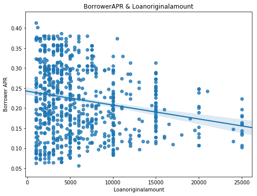

```python
#Scatterplot of Borrowerapr and loanoriginalamount status.
plt.figure(figsize = [8, 6])
sb.regplot(data = loans_samp,y='borrowerapr',x='loanoriginalamount',color=base_color);
plt.title('BorrowerAPR & Loanoriginalamount');
plt.ylabel('Borrower APR');
plt.xlabel('Loanoriginalamount');
```

## Is there correlation between investors and borrowerapr?

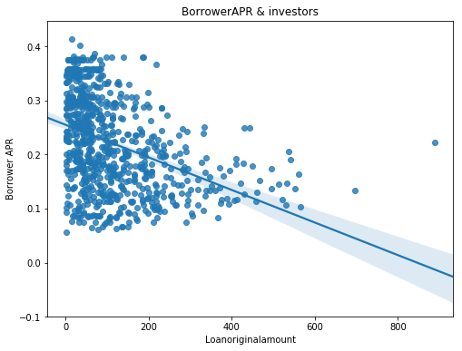

```python
#Scatterplot of Borrowerapr and investors status.
plt.figure(figsize = [8, 6])
sb.regplot(data = loans_samp,y='borrowerapr',x='investors',color=base_color);
plt.title('BorrowerAPR & investors');
plt.ylabel('Borrower APR');
plt.xlabel('Loanoriginalamount');
```

The regplot shows that negative correlation exist btween borrowerapr and loanoriginalamount

## Which loanstatus has the most borrowerapr ?

To check the borrowerapr of default and non-default loanstatus.

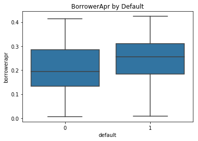

```python
#To show the average mean of borrowerapr by default.
sb.boxplot(data = loan_analysis, x = 'default', y = 'borrowerapr', color = base_color);
plt.title('BorrowerApr by Default');
```

The borrowerapr for default borrower tends to be higher than no default borrower.

## Which incomerange has the most Borrowerapr ?

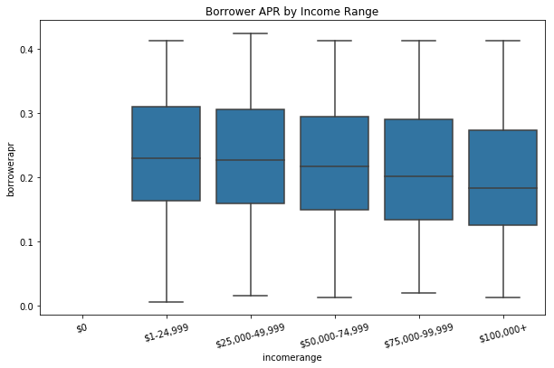

```python
#To show the average mean of borrowerapr by incomerange.
plt.subplots(figsize = (10, 6));
sb.boxplot(data = df_loans, x = 'incomerange', y = 'borrowerapr', color = base_color);
plt.xticks(rotation = 15);
plt.title('Borrower APR by Income Range');
```

The borrowerate decreases at the incomerange increase.

### Did you observe any interesting relationships between the other features (not the main feature(s) of interest)?

> Postive correlation exist between monthloanpayment and originalloanamount.

## Multivariate Exploration

> Create plots of three or more variables to investigate your data even further. Make sure that your investigations are justified, and follow from your work in the previous sections.

```python
df_loans.info()
```

```
<class 'pandas.core.frame.DataFrame'>
Int64Index: 44548 entries, 0 to 113935
Data columns (total 24 columns):
listingcreationdate          44548 non-null datetime64[ns]
term                         44548 non-null int64
loanstatus                   44548 non-null category
closeddate                   44548 non-null datetime64[ns]
borrowerapr                  44548 non-null float64
borrowerrate                 44548 non-null float64
lenderyield                  44548 non-null float64
prosperrating_(alpha)        23020 non-null category
prosperscore                 23020 non-null float64
listingcategory_(numeric)    44548 non-null int64
borrowerstate                44548 non-null object
occupation                   44548 non-null category
employmentstatus             44548 non-null category
amountdelinquent             41651 non-null float64
incomerange                  41494 non-null category
statedmonthlyincome          44548 non-null float64
loancurrentdaysdelinquent    44548 non-null int64
loanoriginalamount           44548 non-null int64
loanoriginationdate          44548 non-null datetime64[ns]
monthlyloanpayment           44548 non-null float64
lp_servicefees               44548 non-null float64
investors                    44548 non-null int64
debttoincomeratio            44548 non-null float64
borrowerstate)               44548 non-null category
dtypes: category(6), datetime64[ns](3), float64(9), int64(5), object(1)
memory usage: 8.0+ MB
```

## Is ther correlation between BorrowerApr,Incomerange and loanstatus.

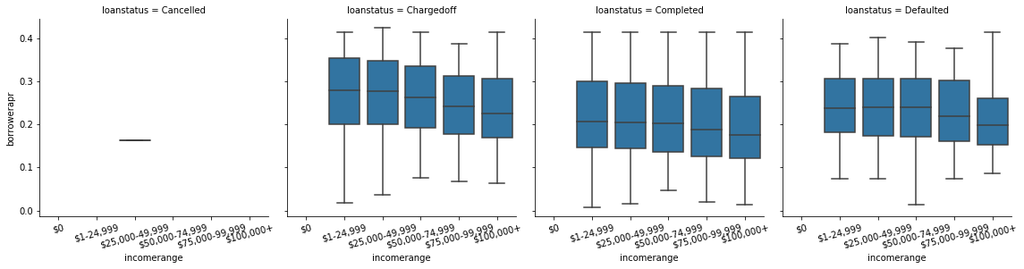

```python
plt.figure(figsize = [8, 6]);
g = sb.FacetGrid(data = df_loans, col = 'loanstatus',col_wrap=4 ,size = 4,margin_titles = True);
g.map(sb.boxplot, 'incomerange', 'borrowerapr');
g.set_xticklabels(rotation = 15);
```

The BorrowerApr tends to decrease has incomeRange increases.

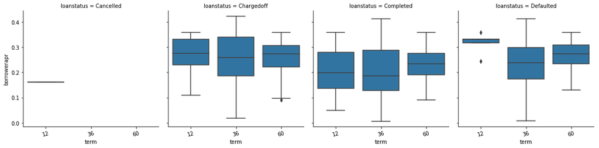

```python
g = sb.FacetGrid(data = df_loans, col = 'loanstatus',col_wrap=4 ,size = 4,margin_titles = True)
g.map(sb.boxplot, 'term', 'borrowerapr');
g.set_xticklabels(rotation = 15);
```

The borrowapr is generally lowest for loanstatus in 36 month term. The mean average for default loan status on the borrowerapr is the highest compared to other loanstatus.

## Is the correlation between lenderyield,borrowerapr and prosperscore ?

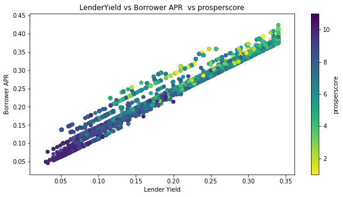

```python
# LenderYield vs Borrower APR  vs Prosperscore
plt.figure(figsize = [10, 5])
plt.scatter(data=df_loans,x='lenderyield', y = 'borrowerapr',c='prosperscore',cmap = 'viridis_r')
plt.colorbar(label = 'prosperscore');
plt.title('LenderYield vs Borrower APR  vs prosperscore');
plt.xlabel('Lender Yield');
plt.ylabel('Borrower APR');
```

The Borrowerapr and lenderyield is postively correlated while both variable(Borrowerapr&lenderyield) is negatively correlated to prosperscore variable.

## Is there relationship between loanoriginalamount and borrowerapr ?

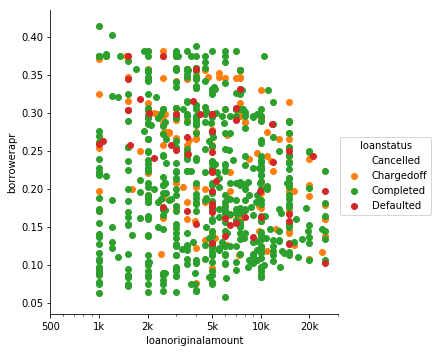

```python
#Plot the loanoriginal amount vs borrowerapr across loanstatus.
plt.figure(figsize = [8,6])
g = sb.FacetGrid(data = loans_samp, hue = 'loanstatus', size = 5)
g.map(plt.scatter, 'loanoriginalamount', 'borrowerapr')
plt.xscale('log')
plt.xticks([500, 1e3, 2e3, 5e3, 1e4, 2e4], [500, '1k', '2k', '5k', '10k', '20k'])
g.add_legend();
```

## Is there correlation between loanoriginalamount,monthlyloanpayment and loanstatus.

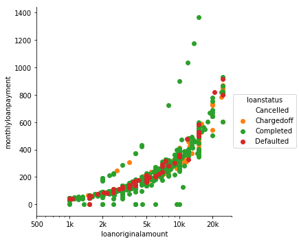

```python
#Plot the loanoriginal amount vs monthlyloanpayment across loanstatus.
plt.figure(figsize = [8,6])
g = sb.FacetGrid(data = loans_samp, hue = 'loanstatus', size = 5)
g.map(plt.scatter, 'loanoriginalamount', 'monthlyloanpayment')
plt.xscale('log')
plt.xticks([500, 1e3, 2e3, 5e3, 1e4, 2e4], [500, '1k', '2k', '5k', '10k', '20k'])
g.add_legend();
```

The current loanstatus shows that if borrowers keep up the monthlyloanpayment they will be on track to complete the payment .

## Is there correlation between prosperscore,borrowerapr and term?

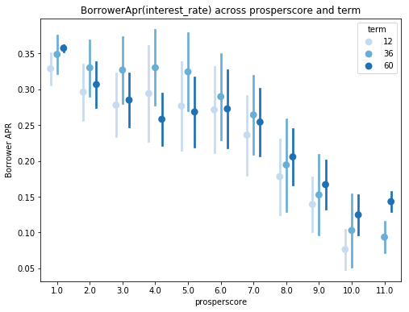

```python
fig = plt.figure(figsize = [8,6])
ax = sb.pointplot(data = df_loans, x = 'prosperscore', y = 'borrowerapr', hue = 'term',
           palette = 'Blues', linestyles = '', dodge = 0.4,ci='sd')
plt.title('BorrowerApr(interest_rate) across prosperscore and term')
plt.ylabel('Borrower APR');
```

The borrowerapr is lowest(0.07) at prosperscore of 10 in the 12 month loans.

### Talk about some of the relationships you observed in this part of the investigation. Were there features that strengthened each other in terms of looking at your feature(s) of interest?

The Borrowerapr and lenderyield is postively correlated while both variable(Borrowerapr&lenderyield) is negatively correlated to prosperscore variable. The Borrowerapr and lenderyield is postively correlated while both variable(Borrowerapr&lenderyield) is negatively correlated to prosperscore variable. The borrowerapr is lowest(0.07) at prosperscore of 10 during the Term period( 12 month loans)

### Were there any interesting or surprising interactions between features?

Scatter plot was plotted for LenderYield vs Borrower APR vs prosperscore.LenderYield vs Borrower APR is postively correlated while negatively correlated across prosper score. lower will be the risk attached hence lower will be the APR and that further lowers down the yield.

## Conclusions

> The loanstatus of borrowers is affected majorly by the employmentstatus,Incomerange and ability to stick with monthloanpayment agreement.